# end_torque

```python
from IPython.display import HTML

HTML('''<script>
code_show=true;
function code_toggle() {
 if (code_show){
 $('div.input').hide();
 } else {
 $('div.input').show();
 }
 code_show = !code_show
}
$( document ).ready(code_toggle);
</script>
<form action="javascript:code_toggle()"><input type="submit" value="Click here to toggle on/off the raw code."></form>''')
```

```python
import numpy as np
import rebound

from scipy.interpolate import interp1d
from scipy.stats import sem


import warnings
warnings.filterwarnings('ignore')

def get_torque(base, n_max=50, suffix=''):
    a_std=np.linspace(1.01, 1.99, 1000)
    tauc=np.zeros(n_max)
    tauc_sign=np.zeros(n_max)
    for ii in range(n_max):
        dat2=np.genfromtxt(base+'_{0}'.format(ii+1)+suffix)
        order=np.argsort(dat2[:,0])
        dat2=dat2[order]
        dat2[:,1]=np.cumsum(dat2[:,1])
        tauc[ii]=(interp1d(dat2[:,0], np.abs(dat2[:,1]))(a_std[-1]))
        tauc_sign[ii]=(interp1d(dat2[:,0], dat2[:,1])(a_std[-1]))

    return np.mean(tauc),sem(tauc), np.mean(tauc_sign)
```

```python
from scipy.interpolate import interp1d
from scipy.stats import sem

base='/home/aleksey/Dropbox/projects/disk_binaries/torque_data/tau_N1000_0.7_'
N=1000
ang_test=[0, 5, 10, 20, 40, 90]
a_test=[0.1, 0.2, 0.5, 1]
torque={}
torque_err={}
torque_sign={}
# torque_b={}
# torque_b_err={}
for a1 in a_test:
    for ang in ang_test:
        base='/home/aleksey/Dropbox/projects/disk_binaries/torque_data/tau_N1000_0.7_'
        base=base+'{0}_{1}'.format(a1, ang)
        tmp=get_torque(base)
        key='{0}_{1:.0g}_{2}'.format(N, a1, ang)
        torque[key], torque_err[key], torque_sign[key]=tmp[0], tmp[1], tmp[2]
#         tmp=get_torque(base, suffix='_b')
#         torque_b[key], torque_b_err[key]=tmp[0], tmp[1]

tmp=get_torque('/home/aleksey/Dropbox/projects/disk_binaries/torque_data/tau_N10000_0.7_1_0')
torque['10000_1_0'], torque_err['10000_1_0'], torque_sign['10000_1_0']=tmp[0], tmp[1], tmp[2]

tmp=get_torque('/home/aleksey/Dropbox/projects/disk_binaries/torque_data/tau_N10000_0.7_1_20')
torque['10000_1_20'], torque_err['10000_1_20'], torque['10000_1_20']=tmp[0], tmp[1], tmp[2]

tmp=get_torque('/home/aleksey/Dropbox/projects/disk_binaries/torque_data/tau_N10000_0.7_0.1_0')
torque['10000_0.1_0'], torque_err['10000_0.1_0'],torque_sign['10000_0.1_0']=tmp[0], tmp[1], tmp[2]

tmp=get_torque('/home/aleksey/Dropbox/projects/disk_binaries/torque_data/tau_N10000_0.7_0.1_20')
torque['10000_0.1_20'], torque_err['10000_0.1_20'], torque_sign['10000_0.1_20']=tmp[0], tmp[1], tmp[2]
```

Consider a test orbit embedded inside of an eccentric disk. The semi-major axis distribution within the disk is $dN/da \propto a^{-1}$ extending from $a=1$ to $a=2$. The disk contains 1000 particles with a small spread in their angular momentum and eccentricity vectors ($\sim 1-2^{\circ}$). All orbits have an eccentricity of 0.7.

The plot below shows the timescale to change the angular momentum of the test orbit as a function of its semi-major axis ($a_{\rm test}$) and its orientation relative to an eccentric nuclear disk ($\bar{\omega}$). This time-scale is defined as

$$t_j\equiv\frac{j_{\rm test}}{\overline{|\tau_z|}},$$

where $\tau_z$ is the z-component of the torque on the test orbit and $j_{\rm test}$ is its angular momentum. $\overline{|\tau_z|}$ is average of the absolute value of the torque on the test orbit over 50 realizations of the disk. The different symbols (diamonds and circles) indicate sign of the torque. Note that the sign of the torque is the same in each realization, except when $\bar{\omega}=0$.

The dashed grey line is the secular timescale within the disk.

We have normalized $t_j$ by the test orbit's period, which decreases with semi-major axis. However, even without this normalization, $t_j$ is still much longer for smaller smas (roghly speaking $\tau \propto a^3$ and $t_j\propto a^{-2.5}$).

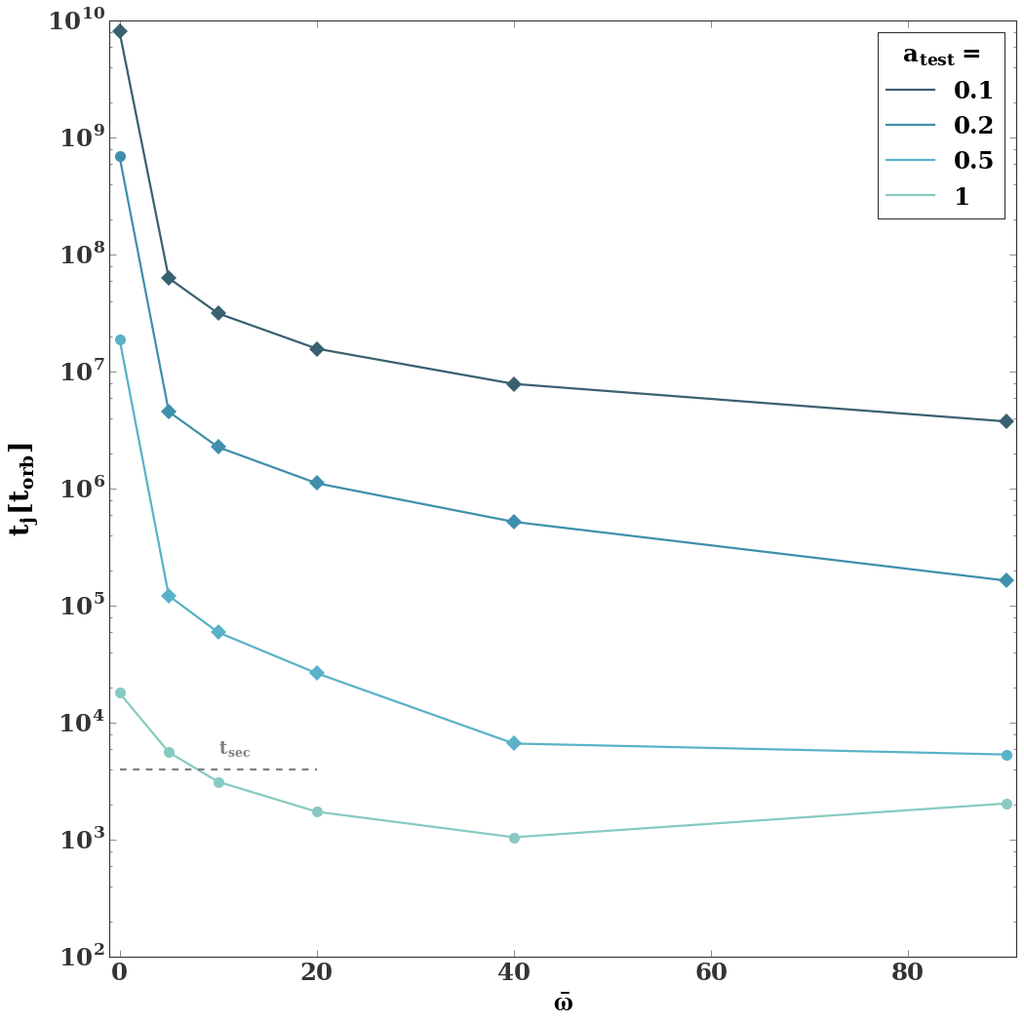

```python
import seaborn as sns
from labelLine import labelLines
# import matplotlib.pyplot as plt

#import matplotlib.pyplot as plt
%pylab inline

# sns.set_context(rc={'lines.markeredgewidth': 0.1})

fig,ax=plt.subplots(figsize=(15,15))
# ax.set_xscale('log')
ax.set_yscale('log')
ax.set_xlim(-1,91)
ax.set_ylim(1e2, 1e10)
ax.set_ylabel(r'$t_j [t_{orb}]$')
ax.set_xlabel(r'$\bar{\omega}$')

# sns.set_style("white")
cols=sns.color_palette('GnBu_d', 4)
N=1000
m=2.5e-7
e=0.7

for ii,a1 in enumerate(a_test):
    col=cols[ii]
    tau_buff=np.empty(len(ang_test))
    tau_buff_b=np.empty(len(ang_test))
    mark=np.empty(len(ang_test), dtype=str)
    for jj,ang in enumerate(ang_test):
        jo=m*(a1*(1.-e**2))**0.5
        torb=(2.*np.pi)*(a1**3)**0.5
        key='{0}_{1}_{2}'.format(N,a1, ang)
        tau_buff[jj]=jo/(torque[key])/(torb)

        mark[jj]=("o" if tau_buff[jj]>0 else "v")
        if torque_sign[key]>0:
            ax.plot(ang_test[jj], abs(tau_buff[jj]), marker="o", color=cols[ii])
        else:
            ax.plot(ang_test[jj], abs(tau_buff[jj]), marker="D", color=cols[ii])
    ax.plot(ang_test, abs(tau_buff), color=cols[ii], label=a1)

ax.legend(title=r'$a_{test}=$')

l1,=ax.plot([0, 10, 15, 20], [4e3, 4e3, 4e3,  4e3], '--', color='0.5', label=r'$t_{sec}$')
labelLines([l1], fontsize=16, xvals=[10])
plt.show()
```

Torque as a function of semi-major axis for $\bar{\omega}=5^{\circ}$. Note that the sign of the torque changes between a=0.5 and a=1.

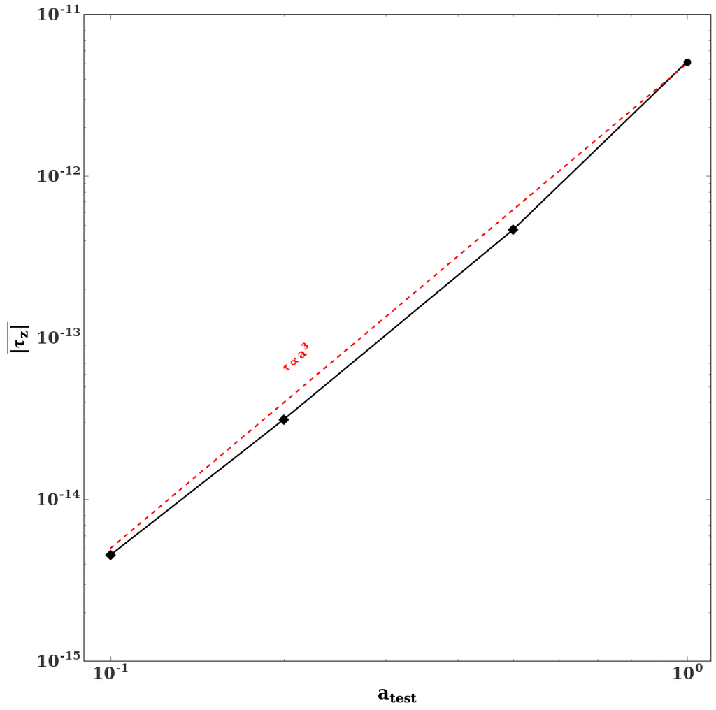

```python
fig,ax=plt.subplots(figsize=(15, 15))
ax.set_ylabel(r'$\overline{|\tau_z|}$')
ax.set_xlabel(r'$a_{test}$')
ax.set_xlim(0.09, 1.1)


a_test=[0.1, 0.2, 0.5, 1]
tmp=np.empty(len(a_test))
for ii,a1 in enumerate(a_test):
    tmp[ii]=torque['1000_{0}_5'.format(a1)]
    if torque_sign['1000_{0}_5'.format(a1)]>0:
        ax.plot(a1, abs(tmp[ii]), "ko")
    else:
        ax.plot(a1, abs(tmp[ii]), "kD")
ax.loglog(a_test, abs(tmp), 'k-')
a_test=np.array(a_test)
l1,=ax.plot(a_test, abs(tmp[0])*1.1*(a_test/a_test[0])**3, 'r--', label=r'$\tau\propto a^3$')
labelLines([l1], fontsize=16, xvals=[0.2], y_offset=0.4)
plt.show()
# loglog(a_test, tau0*np.array(a_test)/0.1), 'r--')
```

Torque as a function of semi-major axis for $\bar{\omega}=90^{\circ}$.

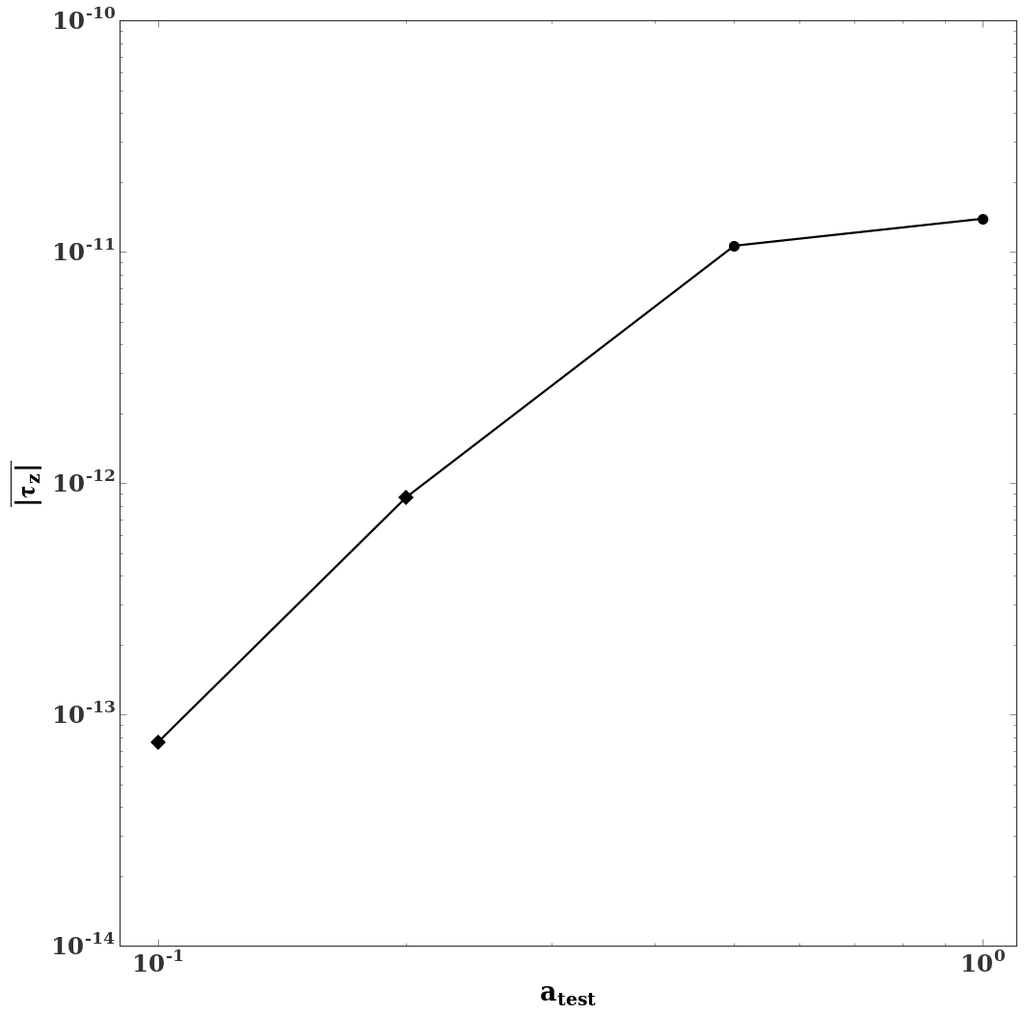

```python
fig,ax=plt.subplots(figsize=(15, 15))
ax.set_xlim(0.09, 1.1)

ax.set_ylabel(r'$\overline{|\tau_z|}$')
ax.set_xlabel(r'$a_{test}$')

# N=1e3
# m=2.5e-7
# a1=0.1
# a0=1
# theta=90.

# tau0=(m)**2*N*a1/a0**2.*np.sin(theta*np.pi/180.)/1.7

a_test=[0.1, 0.2, 0.5, 1]
tmp=np.empty(len(a_test))
for ii,a1 in enumerate(a_test):
    tmp[ii]=torque['1000_{0}_90'.format(a1)]
    if torque_sign['1000_{0}_90'.format(a1)]>0:
        ax.plot(a1, abs(tmp[ii]), "ko")
    else:
        ax.plot(a1, abs(tmp[ii]), "kD")
ax.loglog(a_test, abs(tmp), 'k-')
plt.show()
```

Torque as a function $\bar{\omega}$ for $a_{\rm test}=0.1$. The dashed line is the best fit sine curve to the data. Note the large residual at $\bar{\omega}=90^{\circ}$. In fact it seems $\tau$ scales linearly with $\bar{\omega}$.

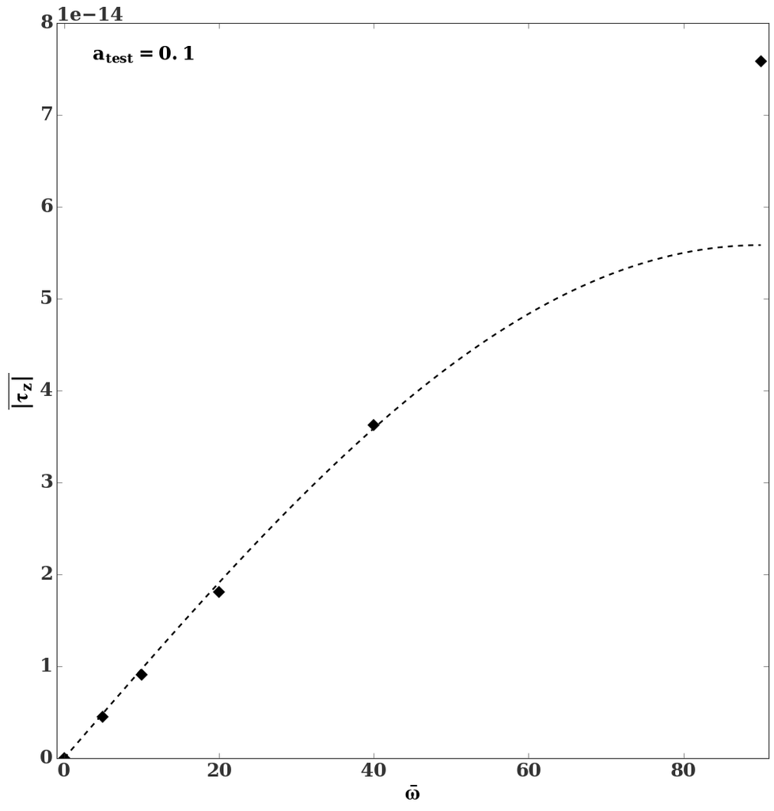

```python
from scipy.optimize import curve_fit

fig,ax=plt.subplots(figsize=(15,15))
ax.set_xlim(-1, 91)
ax.set_ylabel(r'$\overline{|\tau_z|}$')
ax.set_xlabel(r'$\bar{\omega}$')

def fang(a, norm):
    return norm*np.sin(a*np.pi/180)
ang_test2=np.array(ang_test)
tau_buff=np.zeros(len(ang_test))
err=np.zeros(len(ang_test))
ang_ords=np.linspace(0,90,200)


a1=0.1
for jj,ang in enumerate(ang_test2):
    key='{0}_{1}_{2}'.format(int(N),a1, ang)
    tau_buff[jj]=torque[key]
    err[jj]=torque_err[key]
    if torque_sign[key]>0:
        plt.errorbar(ang, tau_buff[jj], err[jj], marker='o', linestyle='', color='k')
    else:
        plt.errorbar(ang, tau_buff[jj], err[jj], marker='D', linestyle='', color='k')

popt,pcov=curve_fit(fang, ang_test, abs(tau_buff), sigma=err)
# print popt[0], pcov[0][0]**0.5
plt.plot(ang_ords, popt[0]*np.sin(ang_ords*np.pi/180), '--', color='k')

ax.annotate(r'$a_{test}=0.1$', (0.05, 0.95), xycoords='axes fraction')
plt.show()
```

Torque as a function of the number of particles ($N$). $\tau\propto N^{p}$, where $0.42 \lesssim p \lesssim 0.66$ for $\bar{\omega}$=0.

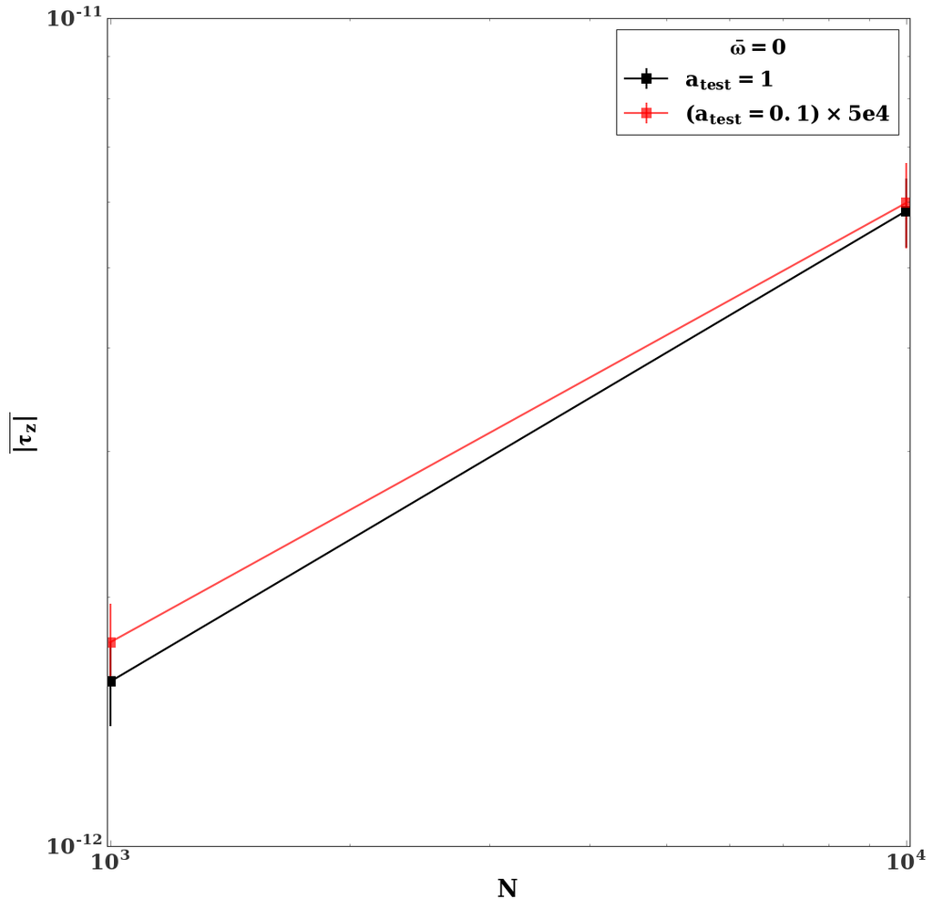

```python
fig,ax=plt.subplots(figsize=(15,15))
ax.set_xlabel('N')
ax.set_xlim(990, 10100)
ax.set_ylabel(r'$\overline{|\tau_z|}$')
ax.set_xscale('log')
ax.set_yscale('log')

a1=1
ang=0
ords=np.array([1000, 10000])
ys=np.array([torque['1000_{0}_{1}'.format(a1, ang)], torque['10000_{0}_{1}'.format(a1,ang)]])
errs=np.array([torque_err['1000_{0}_{1}'.format(a1, ang)], torque_err['10000_{0}_{1}'.format(a1,ang)]])
errorbar(ords, (ys), errs, marker='s', color='k', label=r'$a_{test}=1$')
# print abs(ys),errs
# print np.log((ys[1]+errs[1])/(ys[0]-errs[0]))/np.log(ords[1]/ords[0]), np.log((ys[1])/(ys[0]-errs[0]))/np.log(ords[1]/ords[0]),\
# np.log((ys[1]-errs[1])/(ys[0]+errs[0]))/np.log(ords[1]/ords[0])

a1=0.1
rescale=5.0e4
ords=np.array([1000, 10000])
ys=np.array([torque['1000_{0}_{1}'.format(a1,ang)], torque['10000_{0}_{1}'.format(a1,ang)]])
errs=np.array([torque_err['1000_{0}_{1}'.format(a1, ang)], torque_err['10000_{0}_{1}'.format(a1, ang)]])
errorbar(ords, rescale*ys, rescale*errs, marker='s', color='r', alpha=0.7, label=r'$(a_{test}=0.1)\times 5e4$')

ax.legend(title=r'$\bar{\omega}=$'+'{0}'.format(ang))

# print np.log((ys[1]+errs[1])/(ys[0]-errs[0]))/np.log(ords[1]/ords[0]), np.log((ys[1])/(ys[0]-errs[0]))/np.log(ords[1]/ords[0]),\
#np.log((ys[1]-errs[1])/(ys[0]+errs[0]))/np.log(ords[1]/ords[0])
```

On the other hand $\tau$ is grows linearly with $N$ for misaligned orbits (e.g. the torque scales linearly with the mass in the disk).

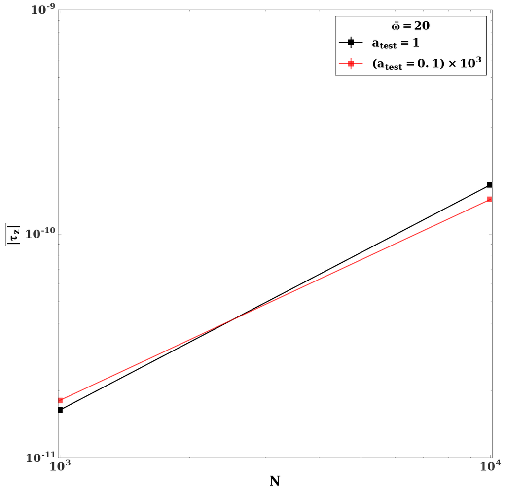

```python
fig,ax=plt.subplots(figsize=(15,15))
ax.set_xlabel('N')
ax.set_xlim(990, 10100)
ax.set_ylabel(r'$\overline{|\tau_z|}$')
ax.set_xscale('log')
ax.set_yscale('log')

a1=1
ang=20
ords=np.array([1000, 10000])
ys=np.array([torque['1000_{0}_{1}'.format(a1, ang)], torque['10000_{0}_{1}'.format(a1,ang)]])
errs=np.array([torque_err['1000_{0}_{1}'.format(a1, ang)], torque_err['10000_{0}_{1}'.format(a1,ang)]])
errorbar(ords, ys, errs, marker='s', color='k', label=r'$a_{test}=1$')

# print np.log((ys[1]+errs[1])/(ys[0]-errs[0]))/np.log(ords[1]/ords[0]), np.log((ys[1])/(ys[0]-errs[0]))/np.log(ords[1]/ords[0]),\
np.log((ys[1]-errs[1])/(ys[0]+errs[0]))/np.log(ords[1]/ords[0])

a1=0.1
rescale=1.0e3
ords=np.array([1000, 10000])
ys=np.array([torque['1000_{0}_{1}'.format(a1,ang)], torque['10000_{0}_{1}'.format(a1,ang)]])
errs=np.array([torque_err['1000_{0}_{1}'.format(a1, ang)], torque_err['10000_{0}_{1}'.format(a1, ang)]])
errorbar(ords, rescale*ys, rescale*errs, marker='s', color='r', alpha=0.7, label=r'$(a_{test}=0.1)\times 10^3$')

ax.legend(title=r'$\bar{\omega}=$'+'{0}'.format(ang))

# print np.log((ys[1]+errs[1])/(ys[0]-errs[0]))/np.log(ords[1]/ords[0]), np.log((ys[1])/(ys[0]-errs[0]))/np.log(ords[1]/ords[0]),\
#np.log((ys[1]-errs[1])/(ys[0]+errs[0]))/np.log(ords[1]/ords[0])
```

To gain intuition we calculate the torques between just two eccentric orbits. In the plot below each point on the outer orbit is colored according to the the torque it exerts on the inner orbit. Note that inner orbit is rotated 90 degrees with respect to the outer orbit.

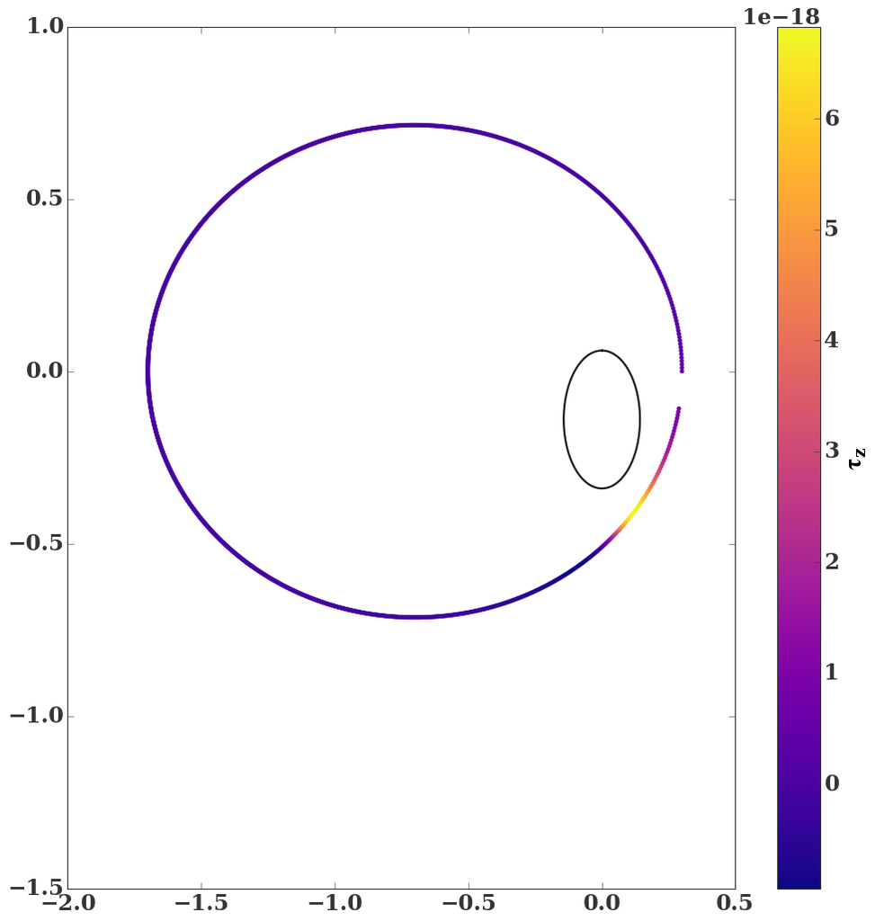

```python
# %pylab inline
fig,ax=plt.subplots(figsize=(15,15))
ax.set_xlim(-2,0.5)
ax.set_ylim(-1.5,1)
dat=np.genfromtxt(loc+'/tau_bin_b__0.7_0.2_90')
import matplotlib.cm as cm


filt=dat[:,2]<0
cols=['red' if ff else 'k' for ff in filt]

# for i in range(len(dat)):
p1=ax.scatter(dat[:-10,0], dat[:-10,1], c=-dat[:-10,2], cmap=cm.plasma)

dat=np.genfromtxt(loc+'/tau_bin__0.7_0.2_90')
# imshow(cm.plasma(dat[:-10, 2]), aspect=2)
ax.plot(dat[:,0], dat[:,1])
fig.colorbar(p1, label=r'$\tau_z$')
plt.show()
```

Torque on the aphelion point of the inner test orbit as a function of its sma ($a_{\rm test}$). Roughly speak $\tau_z \propto a_{\rm test}^3$ for $a_{\rm test} \lesssim 0.2$. Note that the torque reverses sign between $a_{\rm test}$=0.2 and 0.5

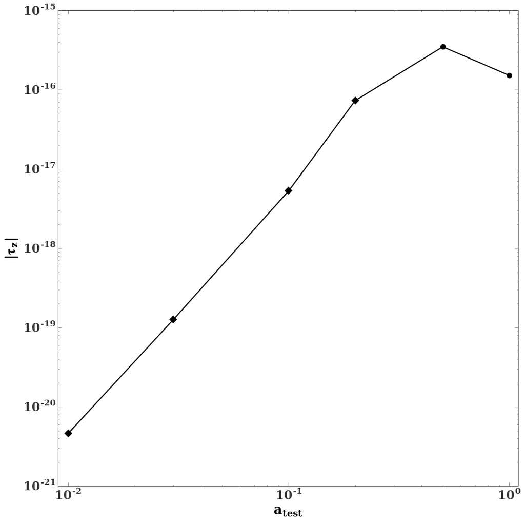

```python
import glob
from scipy.interpolate import interp1d


fig,ax=plt.subplots(figsize=(15, 15))
ax.set_ylabel(r'$|\tau_z|$')
ax.set_xlabel(r'$a_{test}$')
ax.set_xlim(9e-3, 1.1)

loc='/home/aleksey/rebound/examples/end_two_orbits'

fs=glob.glob(loc+'/tau_bin__0.7*_90')
fs=sort(fs)
a_test=[0.01, 0.03, 0.1, 0.2, 0.5, 1]
taus=np.empty(len(a_test))

bins=1500
angs=[j/float(bins)*(2.*np.pi) for j in range(bins)]
for ii,f in enumerate(fs):
    dat=np.genfromtxt(f)
    taus[ii]=interp1d(angs, abs(dat[:,2]))(np.pi)
    tmp=interp1d(angs, dat[:,2])(np.pi)
    if tmp>0:
        loglog(a_test[ii],taus[ii],'ko')
    else:
        loglog(a_test[ii],taus[ii],'kD')
loglog(a_test,taus,'k-')
```

Same as above, but |the test orbit is rotated by only 5$^{\circ}$ with respect to the outer orbit. Note that once again $\tau_z \propto a_{\rm test}^3$ for small a.

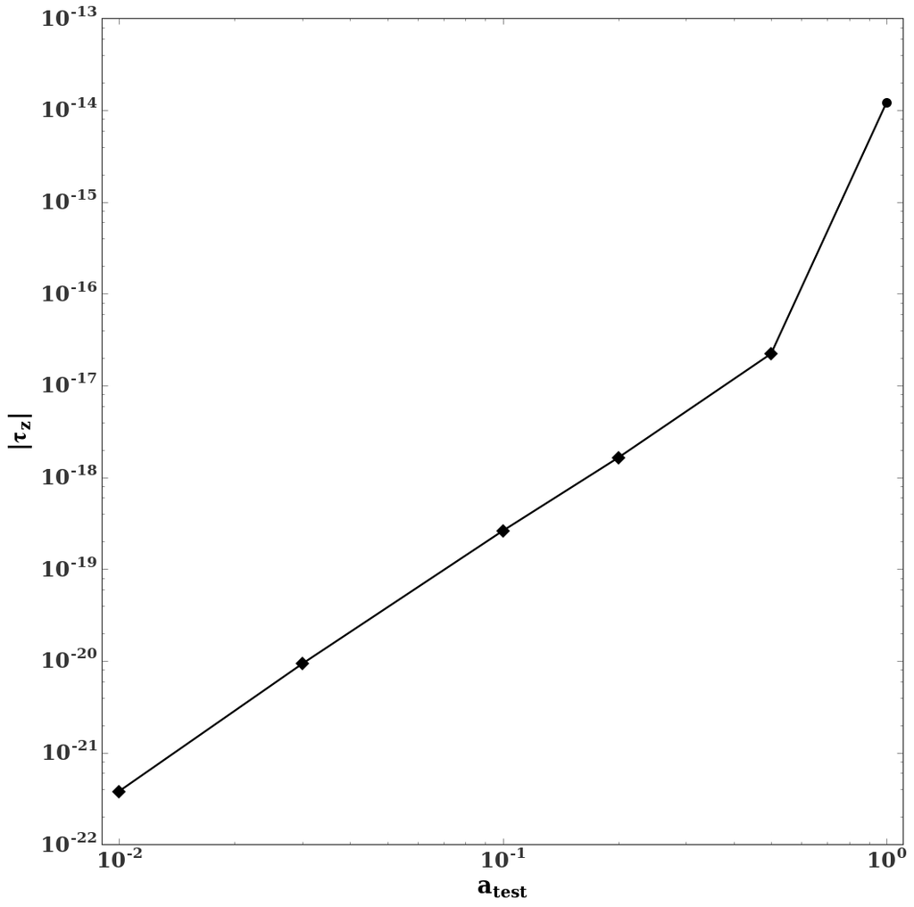

```python
import glob
from scipy.interpolate import interp1d


fig,ax=plt.subplots(figsize=(15, 15))
ax.set_ylabel(r'$|\tau_z|$')
ax.set_xlabel(r'$a_{test}$')
ax.set_xlim(9e-3, 1.1)

loc='/home/aleksey/rebound/examples/end_two_orbits'

fs=glob.glob(loc+'/tau_bin__0.7*_5')
fs=sort(fs)
a_test=[0.01, 0.03, 0.1, 0.2, 0.5, 1]
taus=np.empty(len(a_test))

bins=1500
angs=[j/float(bins)*(2.*np.pi) for j in range(bins)]
for ii,f in enumerate(fs):
    dat=np.genfromtxt(f)
    taus[ii]=interp1d(angs, abs(dat[:,2]))(np.pi)
    tmp=interp1d(angs, dat[:,2])(np.pi)
    if tmp>0:
        loglog(a_test[ii],taus[ii],'ko')
    else:
        loglog(a_test[ii],taus[ii],'kD')
loglog(a_test,taus,'k-')
```